# Introduction to R graphics - `ggplot2` version

Now let’s plot both eggBomb and poisonFang against crabHammer as we did with `lattice`. This again involves some reshaping of the data.

```r
nDat <-
    with(kDat,
         data.frame(sidChar, sidNum, devStage, gType, crabHammer,
                    probeset = factor(rep(c("eggBomb", "poisonFang"),
                                          each = nrow(kDat))),
                    geneExp = c(eggBomb, poisonFang)))
str(nDat)
```

```
## 'data.frame':    78 obs. of  7 variables:
##  $ sidChar   : Factor w/ 39 levels "Sample_1","Sample_10",..: 13 14 15 16 8 9 36 17 18 19 ...
##  $ sidNum    : num  20 21 22 23 16 17 6 24 25 26 ...
##  $ devStage  : Factor w/ 5 levels "E16","P2","P6",..: 1 1 1 1 1 1 1 2 2 2 ...
##  $ gType     : Factor w/ 2 levels "wt","NrlKO": 1 1 1 1 2 2 2 1 1 1 ...
##  $ crabHammer: num  10.22 10.02 9.64 9.65 8.58 ...
##  $ probeset  : Factor w/ 2 levels "eggBomb","poisonFang": 1 1 1 1 1 1 1 1 1 1 ...
##  $ geneExp   : num  7.46 6.89 6.72 6.53 6.47 ...
```

Let’s see what happens if we specify the color in geometries.

```r
# If you type the following code, you will see error: object 'probeset' not found
#(p <- ggplot(nDat, aes(crabHammer, geneExp)) +
#   geom_point(color = probeset))
```

This is a common mistake beginners on `ggplot2` make, especially those who come from base graphics. This is an important difference between **setting** a graphic element and **mapping** some data to the graphic element. When setting graphic elements like color or size in *geom_* functions, that setting applies to *all* data. If you want to use different graphic settings for different groups, you need to *map* that group information to the graphic element inside `aes` function.

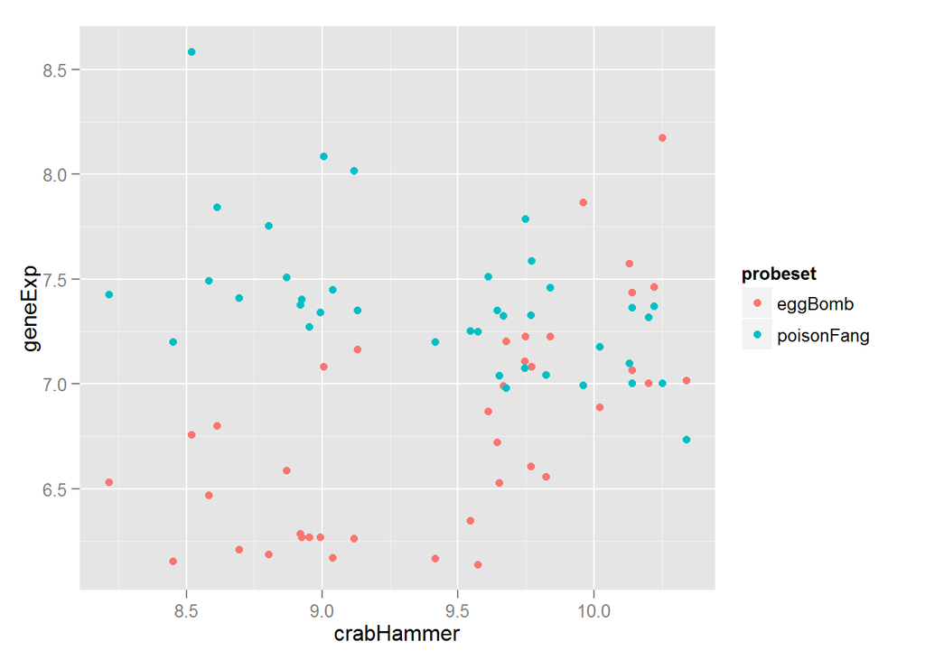

```r
(p <- ggplot(nDat, aes(crabHammer, geneExp, color = probeset)) +
   geom_point())
```

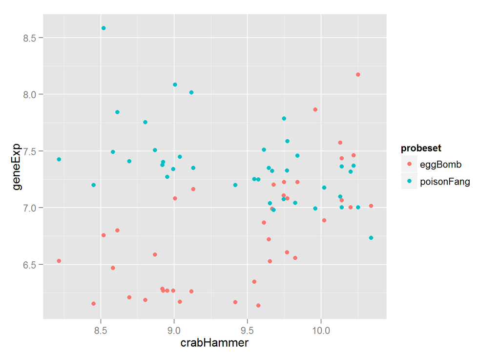

```r
## or the next statement works too
(p <- ggplot(nDat, aes(crabHammer, geneExp)) +
   geom_point(aes(color = probeset)))
```

Let’s try adding a smoothing line now.

```
## geom_smooth: method="auto" and size of largest group is <1000, so using loess. Use 'method = x' to change the smoothing method.
```

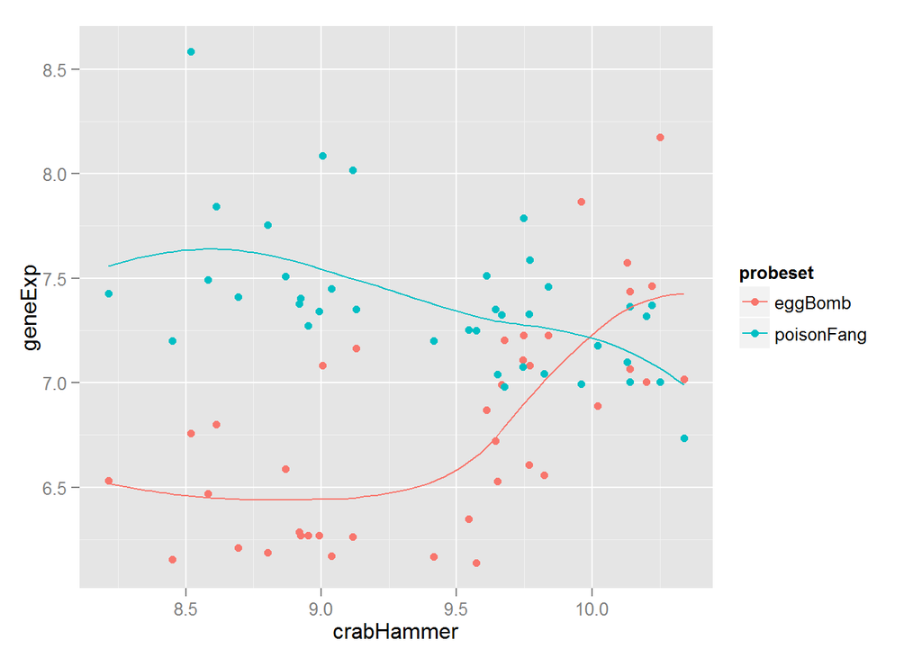

```r
(p <- ggplot(nDat, aes(crabHammer, geneExp, color = probeset)) +
   geom_point() +
   stat_smooth(se = F))
```

> `se = F` will turn off the display of standard error ribbon.

Note in this new layer, a smoothing line was calculated and plotted for *the two different genes*. This is because when we map a categorical variables to an aesthetic as we did with `color = probeset`, we are also defining groups. And by default, groups specified in the *data layer* will be **inherited** by all other layers, but those specified in other layers, like a geometries layer, will not. We can overrule this by specifying another aesthetics in the new layer.

```
## geom_smooth: method="auto" and size of largest group is <1000, so using loess. Use 'method = x' to change the smoothing method.
```

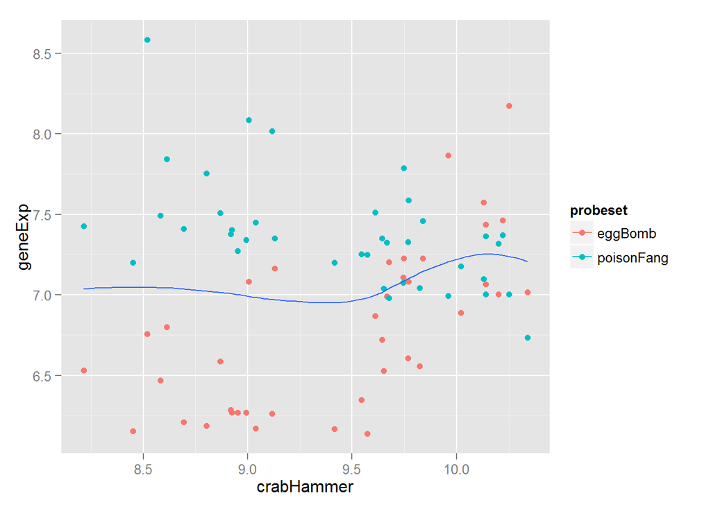

```r
(p <- ggplot(nDat, aes(crabHammer, geneExp, color = probeset)) +
   geom_point() +
   stat_smooth(se = F, aes(group = 1)))
```

If we want to plot `poisonFang ~ crabHammer` and `eggBomb ~ crabHammer` in separated panels, we can use facetting.

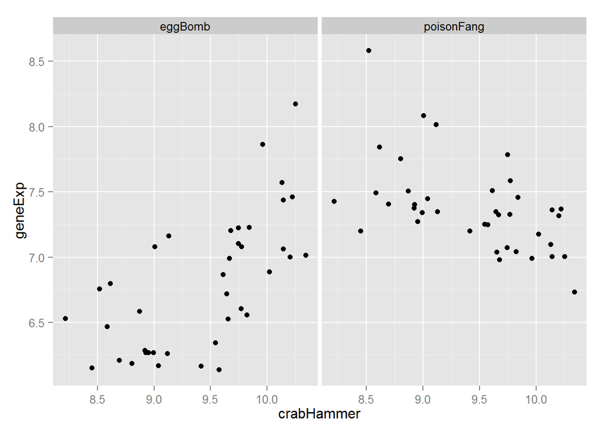

```r
(p <- ggplot(nDat, aes(crabHammer, geneExp)) +
   geom_point() +
   facet_wrap(~ probeset))
```

> For separating panels with two variables, see `facet_grid()`.

We can also distinguish wild type and Nrl knockouts by using different colors.

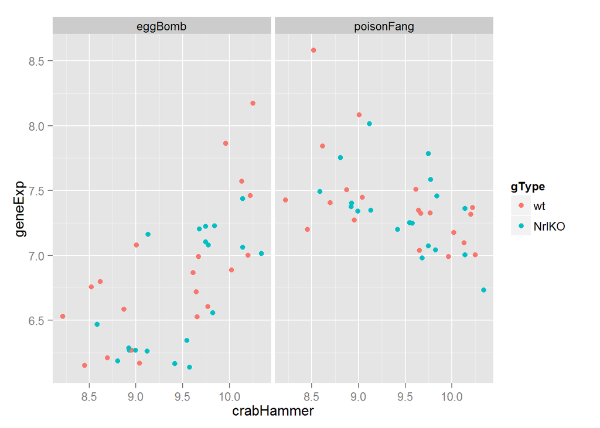

```r
(p <- ggplot(nDat, aes(crabHammer, geneExp, color = gType)) +
   geom_point() +
   facet_wrap(~ probeset))
```

You try: Remake this plot but instead of conveying genotype via color, show developmental stage.

## Stripplot

Stripplots in `ggplot2` still use `geom_point()`, just one of its coordinates is mapped to a `factor` rather then a quantitative variable. We will continue using the examples in the `lattice` seminar. First reshape the dataset so `probeset` will be a factor specifying the gene we are measuring.

```r
oDat <-
  with(kDat,
       data.frame(sidChar, sidNum, devStage, gType,
                  probeset = factor(rep(c("crabHammer", "eggBomb",
                                          "poisonFang"), each = nrow(kDat))),
                  geneExp = c(crabHammer, eggBomb, poisonFang)))
str(oDat)
```

```
## 'data.frame':    117 obs. of  6 variables:
##  $ sidChar : Factor w/ 39 levels "Sample_1","Sample_10",..: 13 14 15 16 8 9 36 17 18 19 ...
##  $ sidNum  : num  20 21 22 23 16 17 6 24 25 26 ...
##  $ devStage: Factor w/ 5 levels "E16","P2","P6",..: 1 1 1 1 1 1 1 2 2 2 ...
##  $ gType   : Factor w/ 2 levels "wt","NrlKO": 1 1 1 1 2 2 2 1 1 1 ...
##  $ probeset: Factor w/ 3 levels "crabHammer","eggBomb",..: 1 1 1 1 1 1 1 1 1 1 ...
##  $ geneExp : num  10.22 10.02 9.64 9.65 8.58 ...
```

Then let’s plot the expression level of each gene.

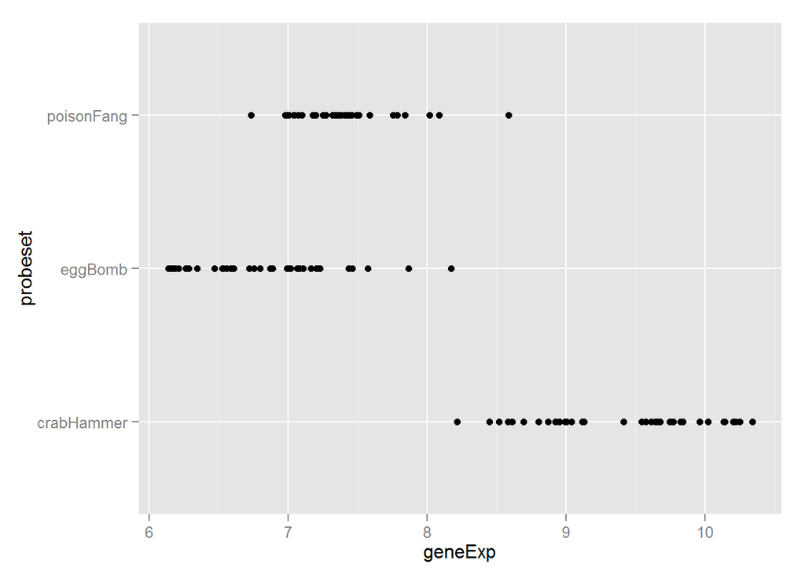

```r
(p <- ggplot(oDat, aes(geneExp, probeset)) +
   geom_point())
```

We can also add jitter.

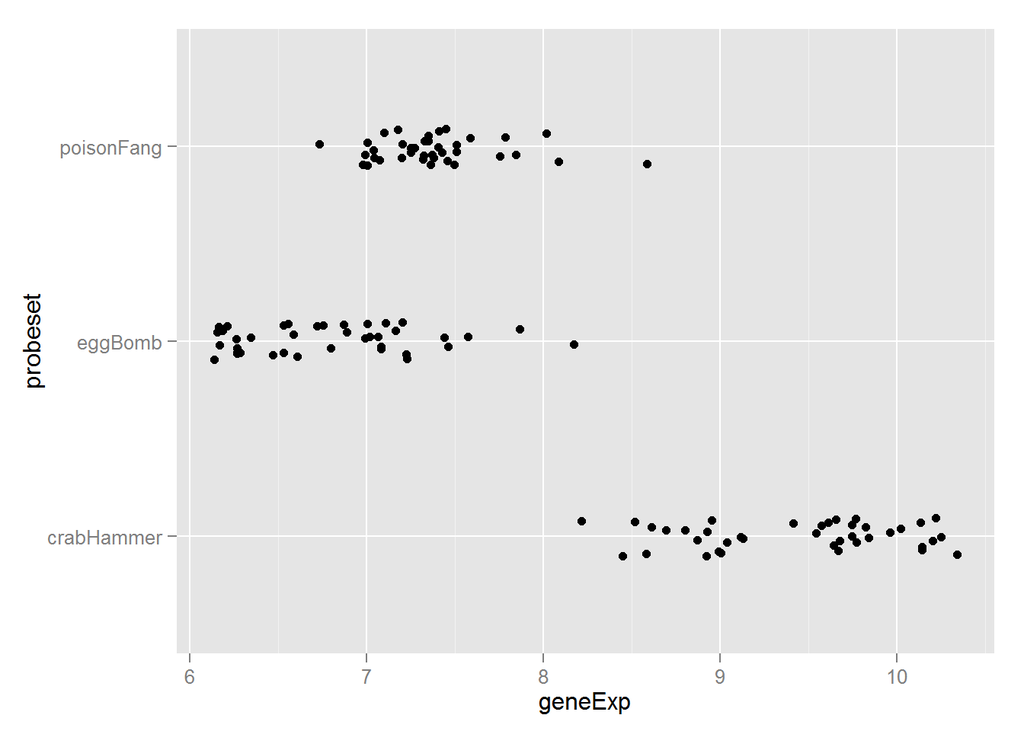

```r
(p <- ggplot(oDat, aes(geneExp, probeset)) +
   geom_point(position = position_jitter(height = 0.1)))
```

Now let’s explore gene expression changes over the course of development.

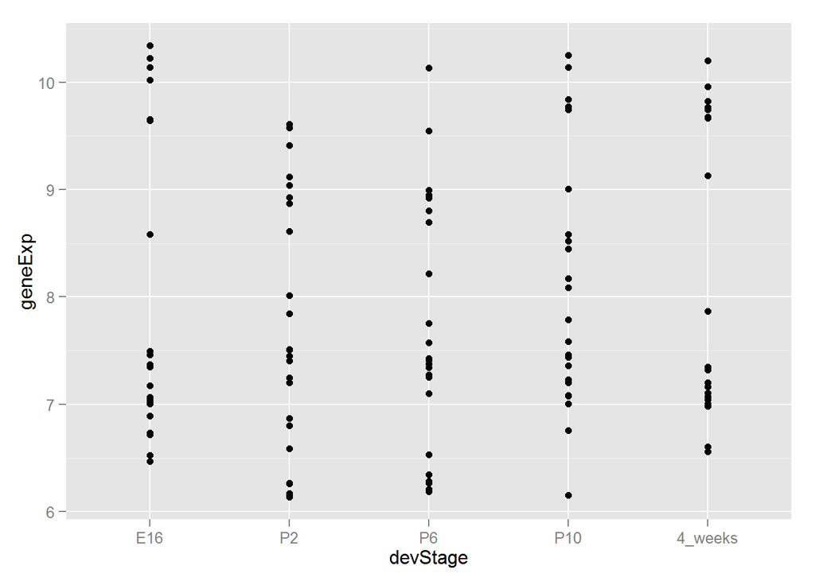

```r
(p <- ggplot(oDat, aes(devStage, geneExp)) +
   geom_point())
```

Show different genes in separate panels.

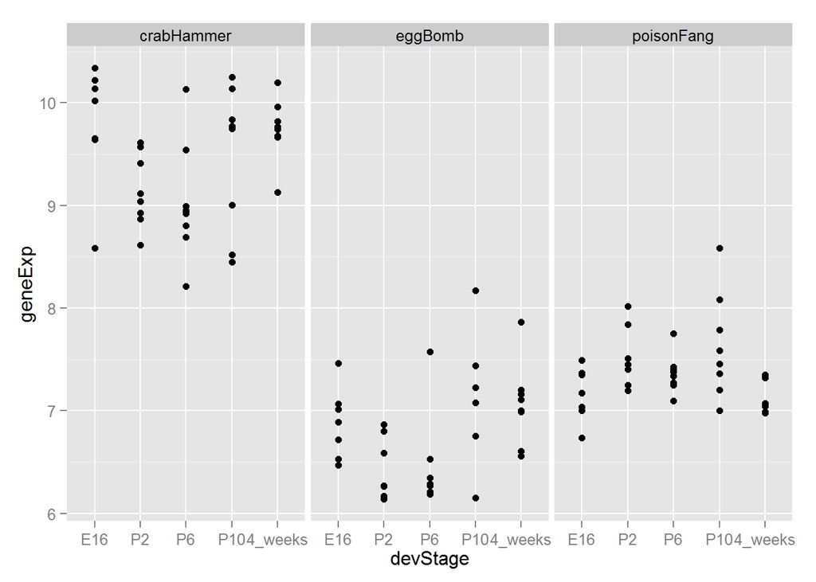

```r
(p <- p + facet_wrap(~ probeset))
```

Add genotype information.

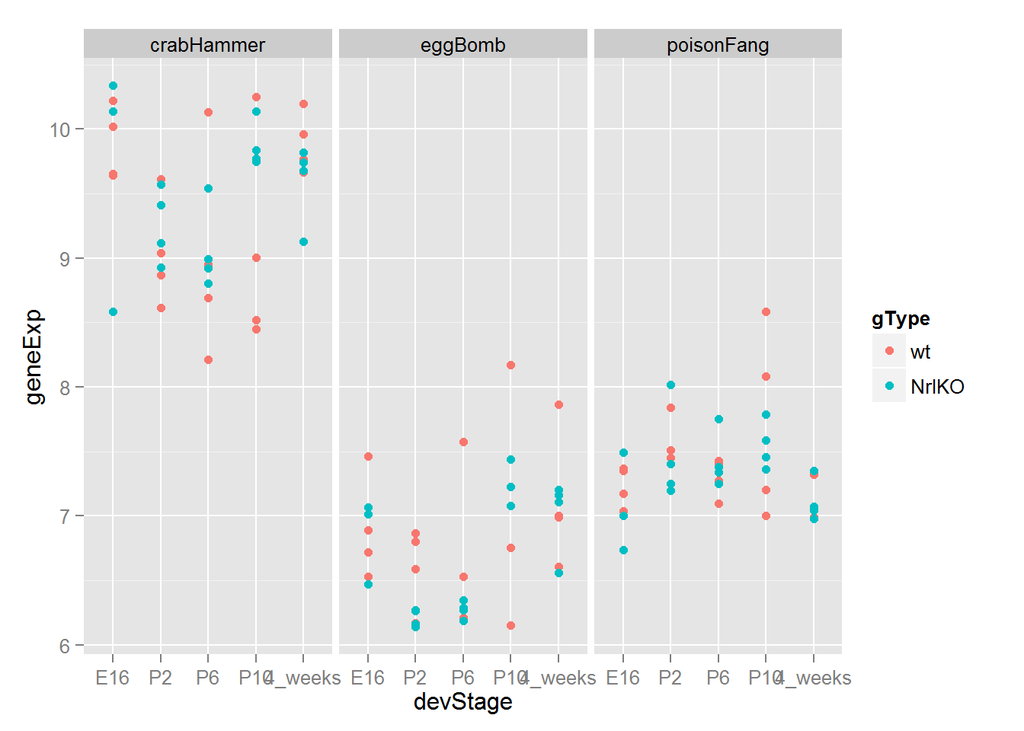

```r
(p <- p + aes(color = gType))
```

Add averages with `stat_summary`.

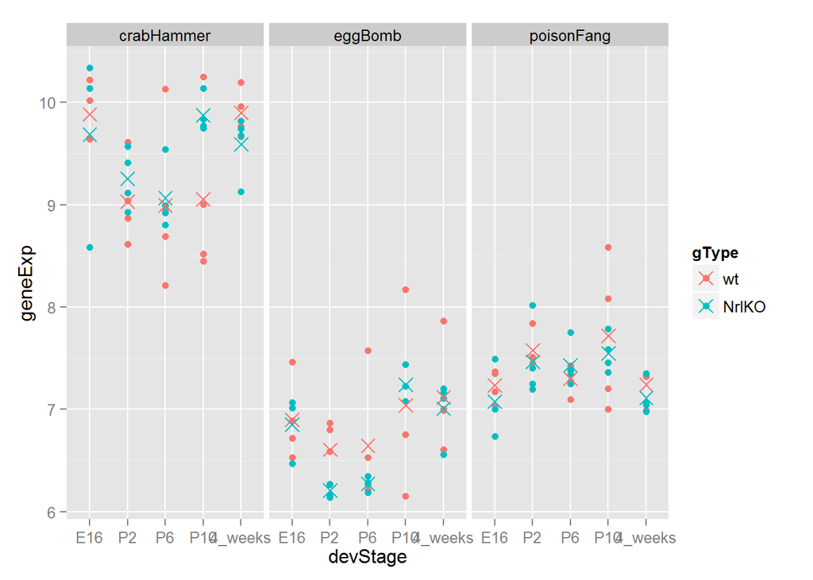

```r
(p <- p + stat_summary(fun.y = mean, geom = "point", shape = 4, size = 4))
```

> The argument `fun.y` will use the function you feed in, in this case `mean`, to summarize y values for every `x`. Alternatively, you can use `fun.data` if you want summary on the entire dataset.

## Density plots

There are two functions `ggplot2` uses for density plots: `geom_density` and `stat_density`. Their default outputs have slightly different flavors.

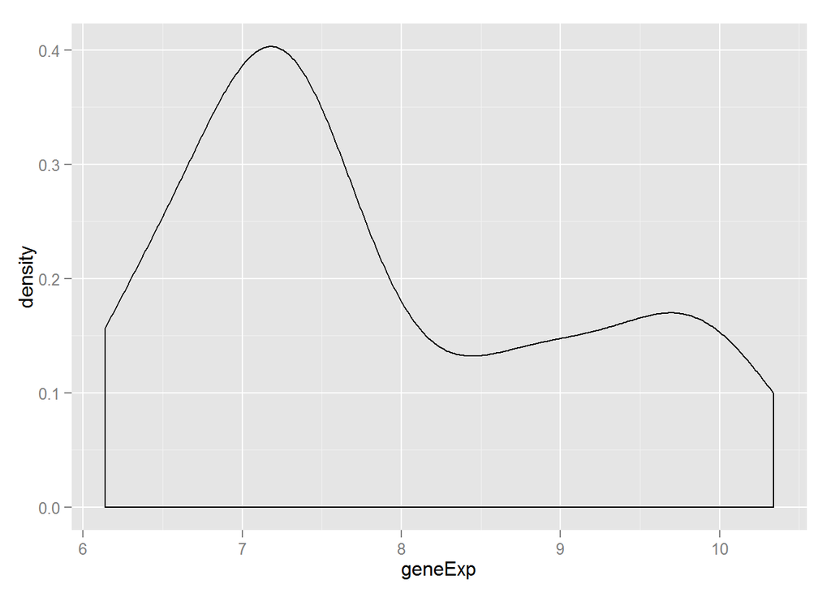

```r
(p <- ggplot(oDat, aes(geneExp)) +
   geom_density())
```

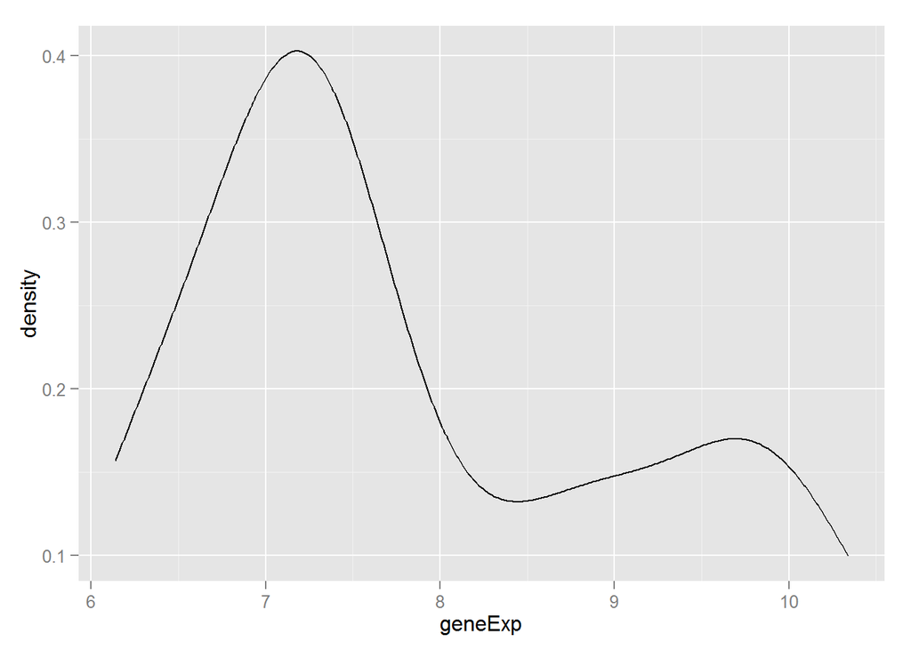

```r
(p <- ggplot(oDat, aes(geneExp)) +
   stat_density(geom = "line", position = "identity"))
```

If you want a more similar presentation to the one we created with `lattice`, i.e. adding data points at the bottom etc.:

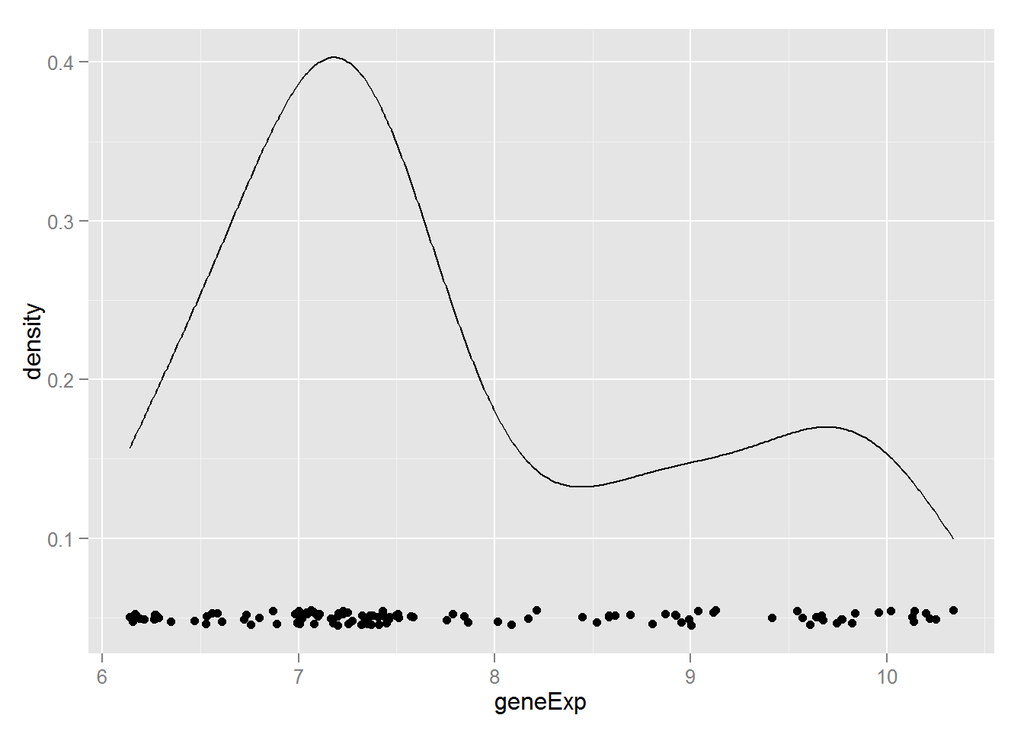

```r
(p <- ggplot(oDat, aes(geneExp)) +
   stat_density(geom = "line", position = "identity") +
   geom_point(aes(y = 0.05), position = position_jitter(height = 0.005)))
```

Change bandwidth with `adjust` argument in `stat_density`.

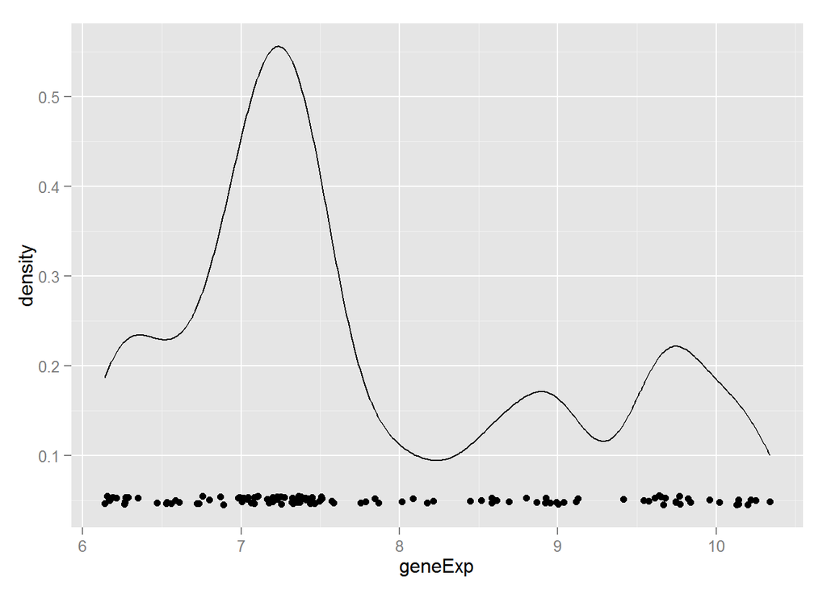

```r
(p <- ggplot(oDat, aes(geneExp)) +
   stat_density(geom = "line", position = "identity", adjust = 0.5) +
   geom_point(aes(y = 0.05), position = position_jitter(height = 0.005)))
```

Separate panels for different genotype.

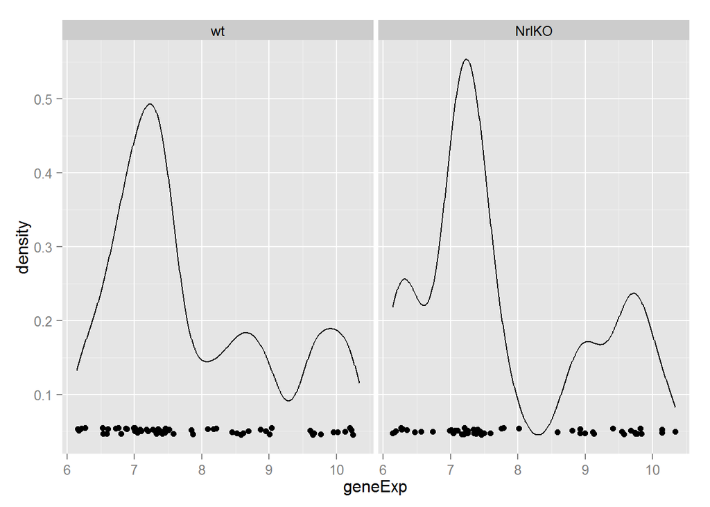

```r
(p <- p + facet_wrap(~ gType))
```

Or different colors for different genotype.

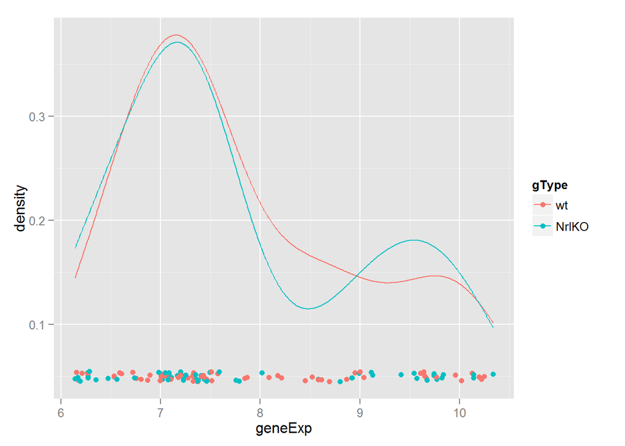

```r
(p <- ggplot(oDat, aes(geneExp, color = gType)) +
   stat_density(geom = "line", position = "identity") +
   geom_point(aes(y = 0.05), position = position_jitter(height = 0.005)))
```

You try: use density plot to explore the gene expression distribution developmental stage. Play with ‘adjust’ if you like.

## Boxplot

The `geom_boxplot` function is available for boxplots in `ggplot2`.

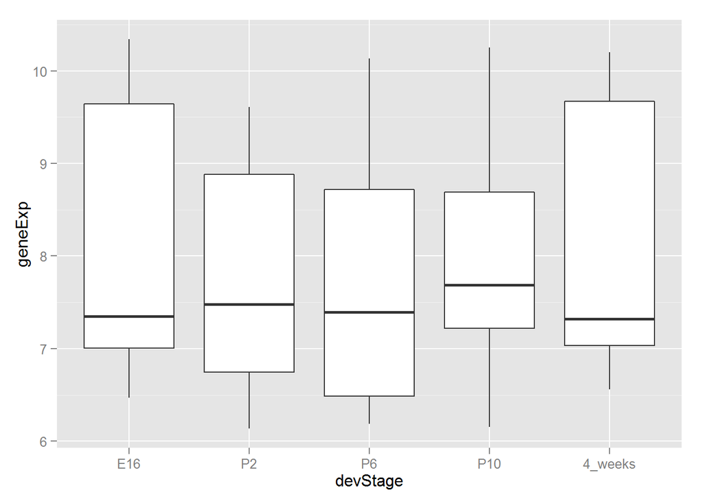

```r
(p <- ggplot(oDat, aes(devStage, geneExp)) +
   geom_boxplot())
```

Separate two genotypes.

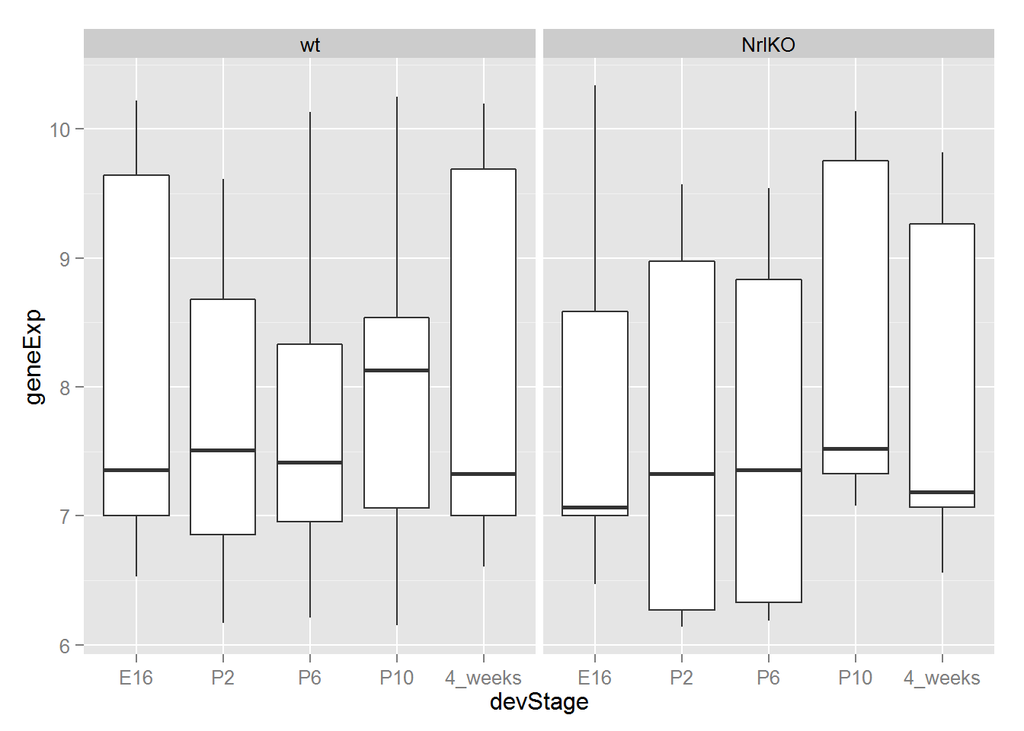

```r
(p <- p + facet_wrap(~ gType))
```

A violinplot is a hybrid of densityplot and histogram.

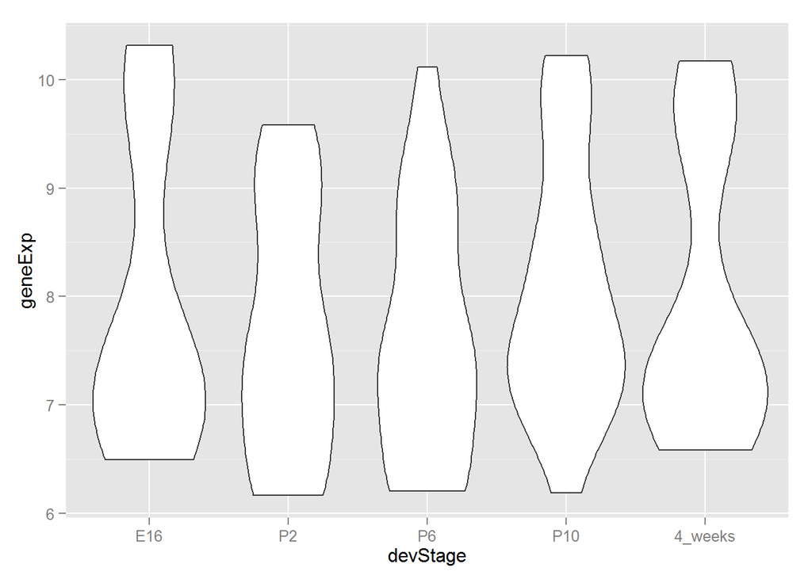

```r
(p <- ggplot(oDat, aes(devStage, geneExp)) +
   geom_violin())
```

## Overplotting and plot matrix

Now let’s load the full data matrix and see how `ggplot2` deals with it.The tsv file could be retrieved from [HERE](https://github.com/STAT540-UBC/STAT540-UBC.github.io/blob/master/examples/photoRec/data/GSE4051_data.tsv). The design rds file can be retrieved from [HERE](https://github.com/STAT540-UBC/STAT540-UBC.github.io/blob/master/examples/photoRec/data/GSE4051_design.rds). Again, save this tsv and rds file in your current working directory, and navigate to the folder where it is stored:

```r
prDat <- read.table("GSE4051_data.tsv")
str(prDat, max.level = 0)
```

```
## 'data.frame':    29949 obs. of  39 variables:
```

```r
## loads an object named 'prDes'
prDes <- readRDS("GSE4051_design.rds")
str(prDes)
```

```
## 'data.frame':    39 obs. of  4 variables:
##  $ sidChar : chr  "Sample_20" "Sample_21" "Sample_22" "Sample_23" ...
##  $ sidNum  : num  20 21 22 23 16 17 6 24 25 26 ...
##  $ devStage: Factor w/ 5 levels "E16","P2","P6",..: 1 1 1 1 1 1 1 2 2 2 ...
##  $ gType   : Factor w/ 2 levels "wt","NrlKO": 1 1 1 1 2 2 2 1 1 1 ...
```

First let’s pick two samples at random to plot against each other.

```r
set.seed(2)
(yo <- sample(1:ncol(prDat), size = 2))
```

```
## [1]  8 27
```

```r
bDat <- data.frame(y = prDat[[yo[1]]], z = prDat[[yo[2]]])
str(bDat)
```

```
## 'data.frame':    29949 obs. of  2 variables:
##  $ y: num  7.11 9.75 9.39 8.37 8.36 ...
##  $ z: num  7.15 9.22 10.06 8.35 8.45 ...
```

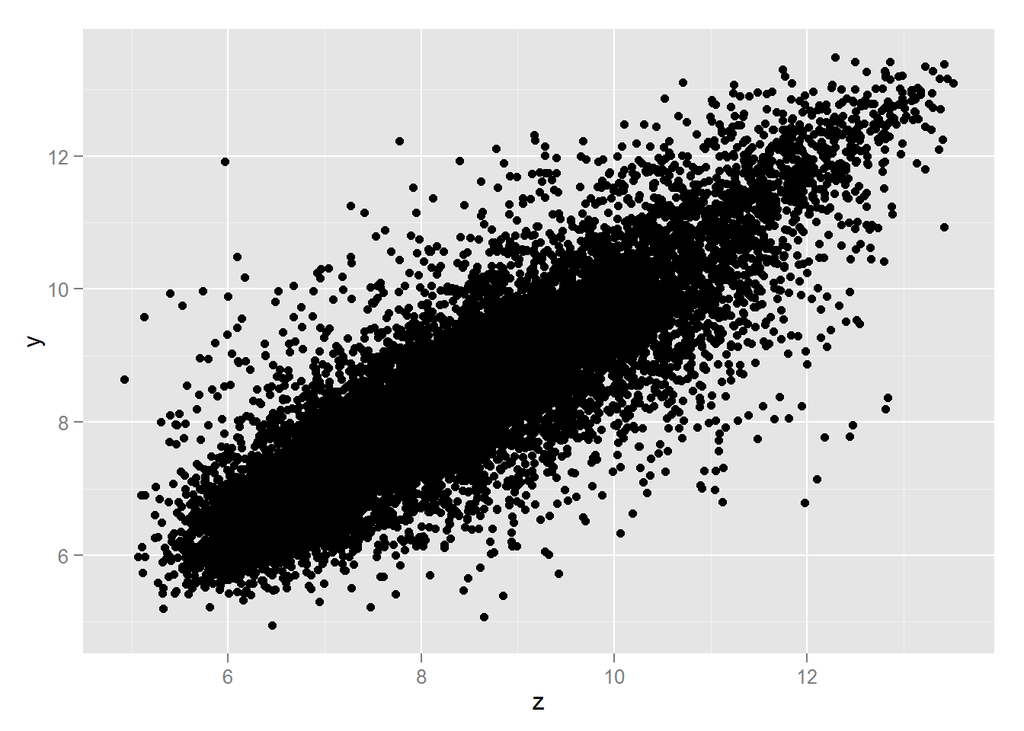

```r
(p <- ggplot(bDat, aes(z, y)) +
   geom_point())
```

You will notice that `ggplot2` is often slower to produce a figure than `lattice`.

One quick way to get a more informative plot is simply reducing the transparency of the data point with `alpha` argument. It has a somewhat similar effect to `smoothScatter` function.

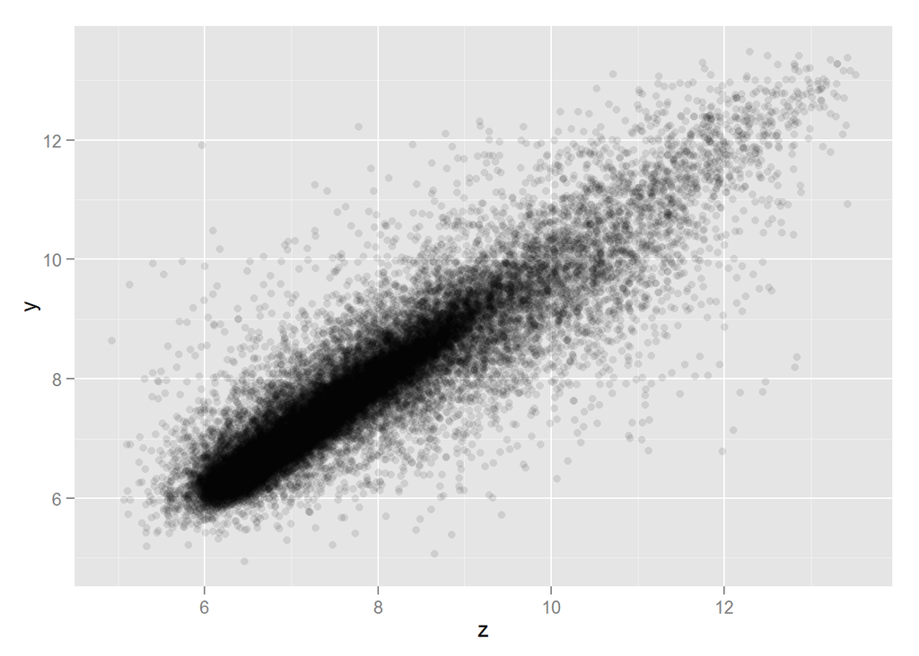

```r
(p <- ggplot(bDat, aes(z, y)) +
   geom_point(alpha = 0.1))
```

Another way to present is to use the `density2d` function. The idea is similar to `smoothScatter` plots.

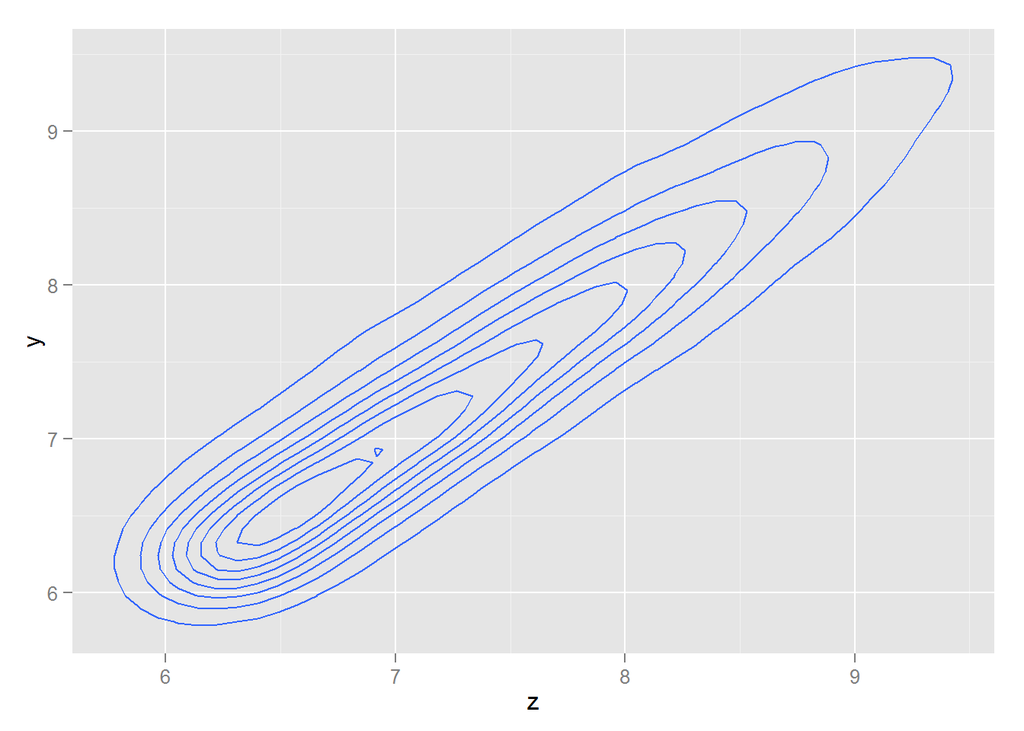

```r
(p <- ggplot(bDat, aes(z, y)) +
   stat_density2d())
```

It looks a bit weird now, but if you use colors gradient instead of lines, it will make more sense.

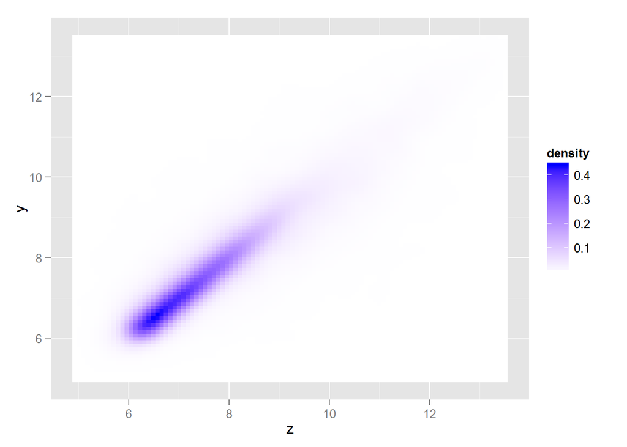

```r
(p <- ggplot(bDat, aes(z, y)) +
   stat_density2d(geom = "tile", contour = F, aes(fill = ..density..)) +
   scale_fill_gradient(low = "white", high = "blue"))
```

> Some functions especially `stat` functions return also their own calculated values. You can use these values by calling *..[value name]..*, e.g. the use of `fill = ..density..` here.

`ggplot2` also offers `stat_binhex` function similar to the `hexbin` package.

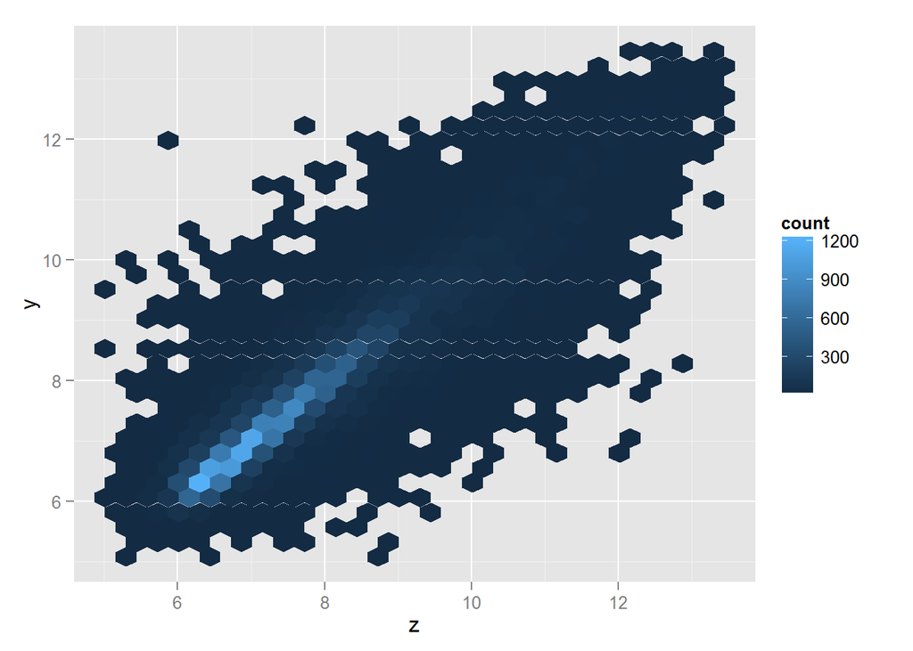

```r
# if the following code doesn't work, try first: install.packages("hexbin")
library(hexbin)
(p <- ggplot(bDat, aes(z, y)) +
   stat_binhex())
```

For pairwise scatterplots, you can also use the new `ggpairs` function in `GGally`. Again, we need to take a larger sample of columns now.

```r
set.seed(3)
(yo <- sample(1:ncol(prDat), size = 4))
```

```
## [1]  7 31 15 12
```

```r
pairDat <- subset(prDat, select = yo)
str(pairDat)
```

```
## 'data.frame':    29949 obs. of  4 variables:
##  $ Sample_6 : num  7.24 9.71 10.17 8.84 8.54 ...
##  $ Sample_19: num  7.21 9.21 9.59 8.31 8.31 ...
##  $ Sample_8 : num  7.11 8.24 9.13 8.13 8.33 ...
##  $ Sample_14: num  7.09 9.56 9.88 8.57 8.59 ...
```

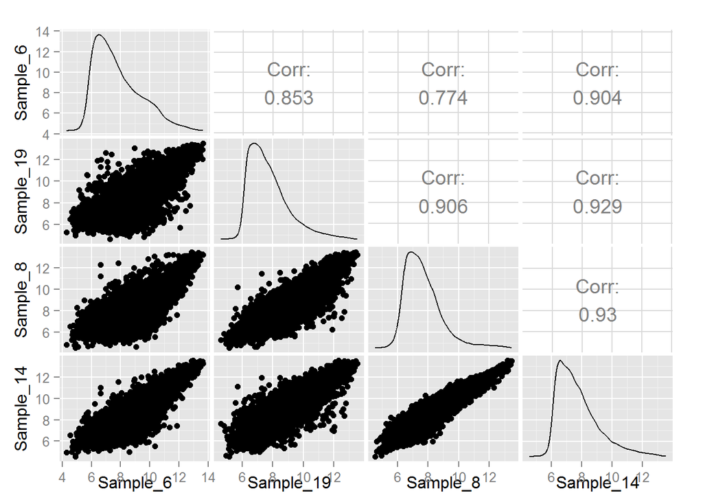

```r
# if you haven't installed GGally, type:
# install.packages("GGally")
library(GGally)
(p <- ggpairs(pairDat))
```

## Heatmap

> JB note: inserting code provided by student Dean Attali via [this Gist](https://gist.github.com/daattali/8609489)

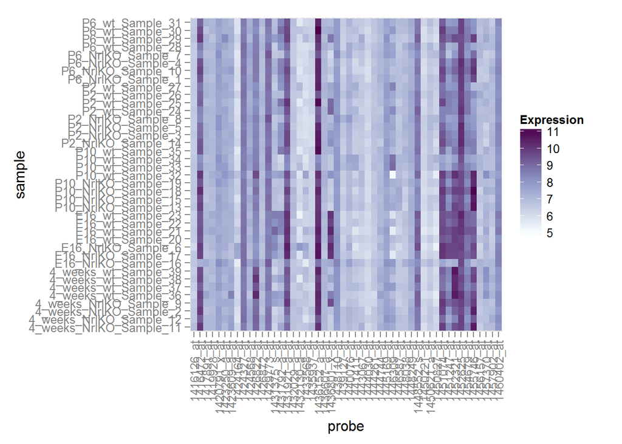

```r
library(RColorBrewer)

# set seed so that we have exactly reproducable results
set.seed(1)

# choose 50 probes out of the 30k to work with
yo <- sample(1:nrow(prDat), size = 50)
hDat <- prDat[yo, ]
colnames(hDat) <- with(prDes, paste(devStage, gType, sidChar, sep = "_"))

# transform the data to tall format
prDatTall <- data.frame(sample = rep(colnames(hDat), each = nrow(hDat)),
                        probe = rownames(hDat),
                        expression = unlist(hDat))

# create a blue -> purple palette
jBuPuFun <- colorRampPalette(brewer.pal(n = 9, "BuPu"))
paletteSize <- 256
jBuPuPalette <- jBuPuFun(paletteSize)

# heatmap!
ggplot(prDatTall, aes(x = probe, y = sample, fill = expression)) +
  theme(axis.text.x = element_text(angle = 90, hjust = 1, vjust = 0.5)) +
  geom_tile() +
  scale_fill_gradient2(low = jBuPuPalette[1],
                       mid = jBuPuPalette[paletteSize/2],
                       high = jBuPuPalette[paletteSize],
                       midpoint = (max(prDatTall$expression) +
                                     min(prDatTall$expression)) / 2,
                       name = "Expression")
```

## Take-home problem

The full `photoRec` dataset has 39 samples and 29,949 probesets. Choose 2 … or 20 … or 200 random probesets/genes and look for gene expression differences between the two genotypes, wild type versus knockout. Make use of the graphing techniques discussed this week such as scatter plots, box plot, etc. Share questions, success, failure on the Google group.

## Added 2014-03-31

Via Dean Attali: [Extra! Extra! Get Your gridExtra!](http://www.imachordata.com/extra-extra-get-your-gridextra/) blog post on using `gridExtra` to assemble multiple `ggplot2` plots on one “page”